# Assignment_Prabisha

# Task 2.7 – Train/Test Split, Prediction, CI, Metrics, and Plot

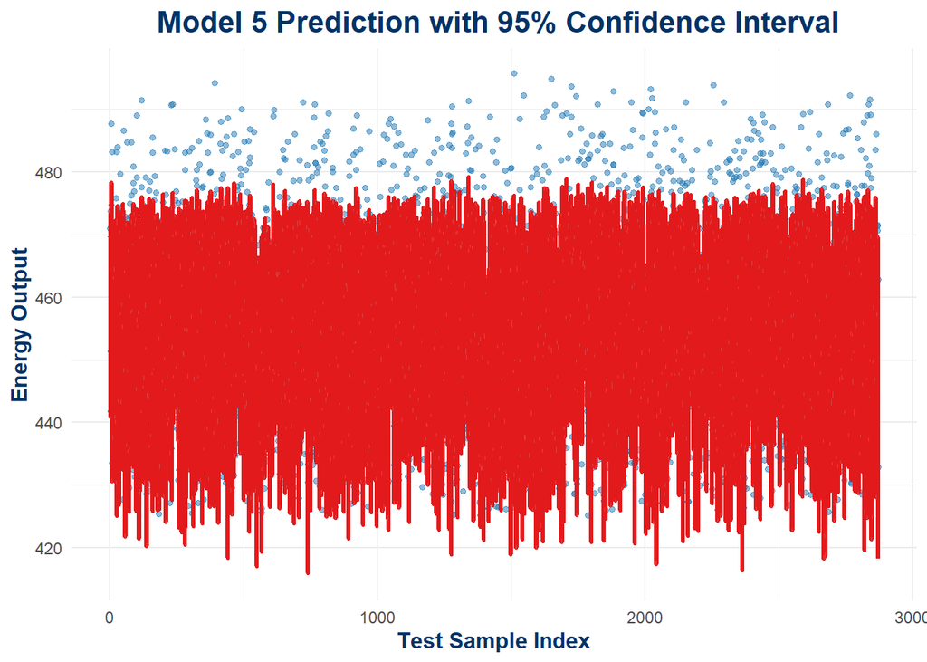

```r
# Step 1: Prepare full data for Model 5 (x4, x1², x3²)
data_full <- data.frame(
  x4 = X$Humidity,
  x1_sq = X$Temperature^2,
  x3_sq = X$Pressure^2,
  y = Y
)

# Step 2: Train-test split (70% training)
set.seed(123)
split_data <- initial_split(data_full, prop = 0.7)
train_data <- training(split_data)
test_data  <- testing(split_data)

# Step 3: Fit Model 5 on training set
model5_train <- lm(y ~ x4 + x1_sq + x3_sq, data = train_data)

# Step 4: Predict on test set with 95% confidence interval
pred_test <- predict(model5_train, newdata = test_data, interval = "confidence", level = 0.95)

# Step 5: Prepare results dataframe
results <- data.frame(
  Index = 1:nrow(test_data),
  Observed = test_data$y,
  Predicted = pred_test[, "fit"],
  Lower_CI = pred_test[, "lwr"],
  Upper_CI = pred_test[, "upr"]
)

# Step 6: Plot predictions with CI
ggplot(results, aes(x = Index)) +
  geom_point(aes(y = Observed), color = "#1f78b4", size = 1.2, alpha = 0.5) +
  geom_line(aes(y = Predicted), color = "#e31a1c", linewidth = 1.2) +
  geom_ribbon(aes(ymin = Lower_CI, ymax = Upper_CI), fill = "gray70", alpha = 0.3) +
  labs(
    title = " Model 5 Prediction with 95% Confidence Interval",
    x = "Test Sample Index", y = "Energy Output"
  ) +
  theme_minimal() +
  theme(
    plot.title = element_text(face = "bold", size = 16, hjust = 0.5, color = "#003366"),
    axis.title = element_text(face = "bold", size = 12, color = "#003366")
  )
```

```r
# Calculate model performance metrics (RMSE, MAE, R²)
test_resids <- test_data$y - pred_test[, "fit"]

rmse_val <- Metrics::rmse(test_data$y, pred_test[, "fit"])
mae_val  <- Metrics::mae(test_data$y, pred_test[, "fit"])
r2_val   <- 1 - sum(test_resids^2) / sum((test_data$y - mean(test_data$y))^2)
```

```r
# Create summary table of performance metrics
metrics_df <- data.frame(
  Metric = c("RMSE", "MAE", "R²"),
  Value = c(round(rmse_val, 4), round(mae_val, 4), round(r2_val, 4))
)

metrics_df %>%
  kbl(
    caption = "Model 5 Performance Metrics on Test Data",
    align = "c"
  ) %>%
  kable_styling(
    bootstrap_options = c("striped", "hover", "condensed"),
    full_width = FALSE,
    position = "center"
  ) %>%
  row_spec(0, bold = TRUE, background = "#2c3e50", color = "white") %>%
  column_spec(1, bold = TRUE, width = "6cm", border_right = TRUE)
```

Model 5 Performance Metrics on Test Data

| Metric | Value |
| --- | --- |
| RMSE | 6.0971 |
| MAE | 4.8592 |
| R² | 0.8727 |

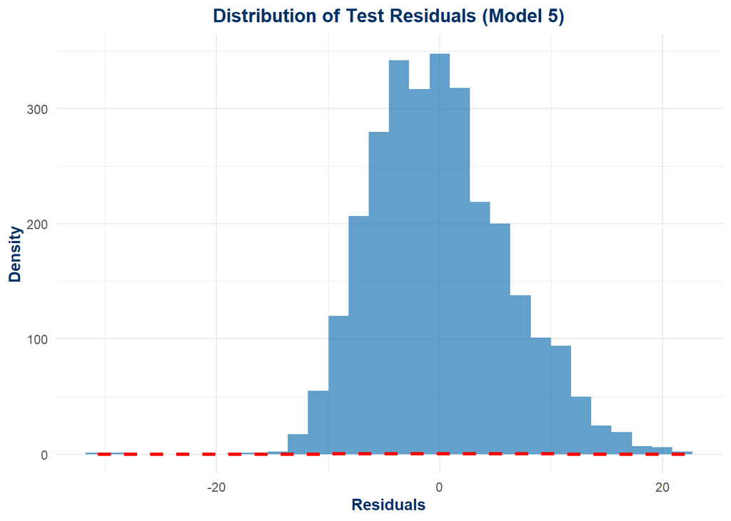

```r
# Step 10: Visualize test residuals
ggplot(data.frame(test_resids), aes(x = test_resids)) +
  geom_histogram(bins = 30, fill = "#1f78b4", alpha = 0.7) +
  geom_density(color = "red", linewidth = 1.2, linetype = "dashed") +
  labs(
    title = "Distribution of Test Residuals (Model 5)",
    x = "Residuals", y = "Density"
  ) +
  theme_minimal() +
  theme(
    plot.title = element_text(face = "bold", hjust = 0.5, color = "#003366"),
    axis.title = element_text(face = "bold", color = "#003366")
  )
```

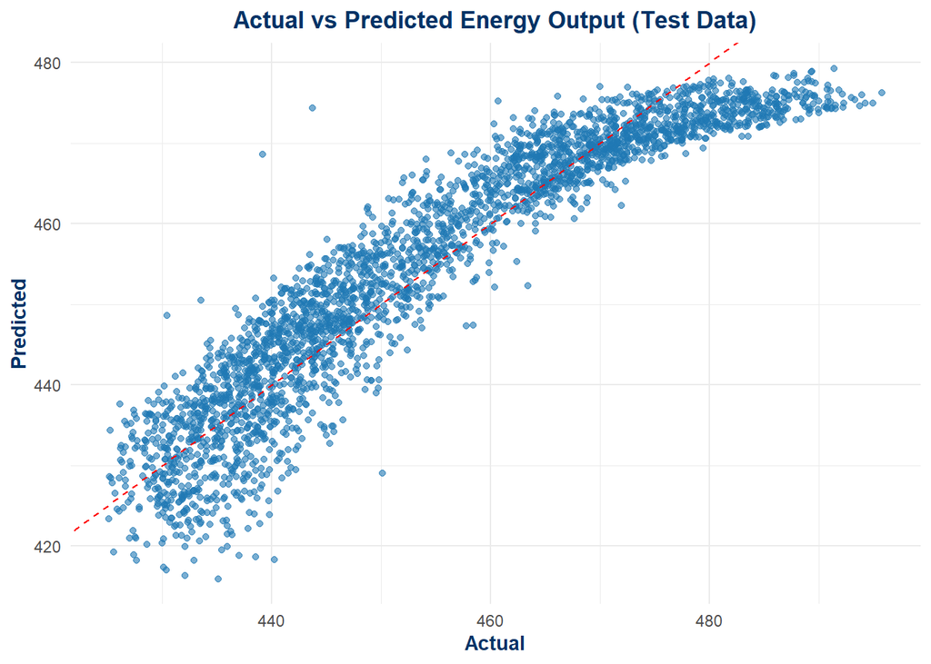

```r
#  Actual vs. Predicted Plot
ggplot(results, aes(x = Observed, y = Predicted)) +
  geom_point(color = "#1f78b4", alpha = 0.6) +
  geom_abline(intercept = 0, slope = 1, color = "red", linetype = "dashed") +
  labs(
    title = "Actual vs Predicted Energy Output (Test Data)",
    x = "Actual", y = "Predicted"
  ) +
  theme_minimal() +
  theme(
    plot.title = element_text(face = "bold", hjust = 0.5, color = "#003366"),
    axis.title = element_text(face = "bold", color = "#003366")
  )
```

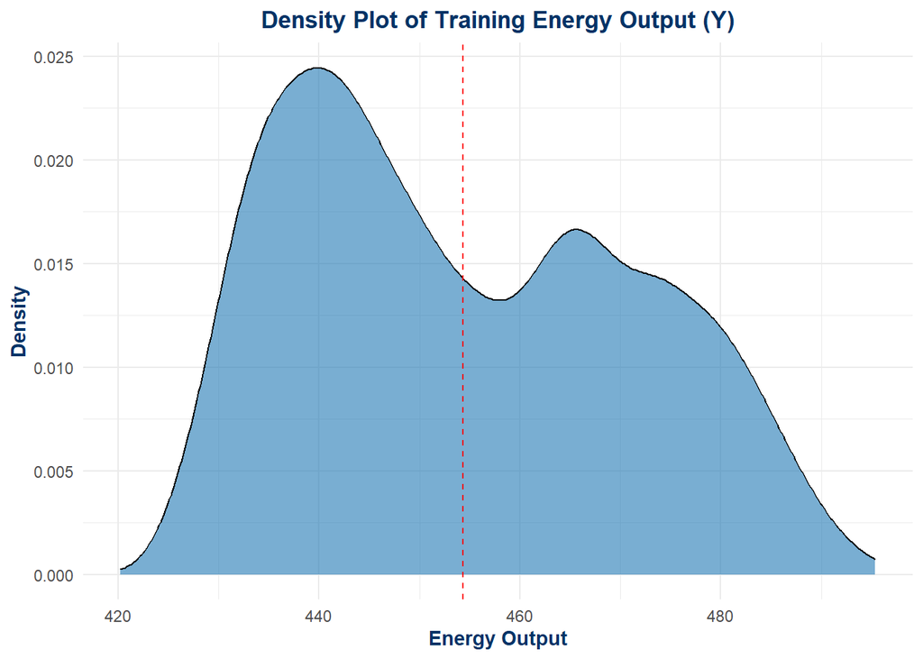

```r
# Density plot of training Y
ggplot(data.frame(y_train = train_data$y), aes(x = y_train)) +
  geom_density(fill = "#1f78b4", alpha = 0.6) +
  geom_vline(xintercept = mean(train_data$y), color = "red", linetype = "dashed") +
  labs(
    title = "Density Plot of Training Energy Output (Y)",
    x = "Energy Output", y = "Density"
  ) +
  theme_minimal() +
  theme(
    plot.title = element_text(face = "bold", hjust = 0.5, color = "#003366"),
    axis.title = element_text(face = "bold", color = "#003366")
  )
```

```r
# Using training data from split
X_manual <- cbind(
  1,
  train_data$x4,
  train_data$x1_sq,
  train_data$x3_sq
)

Y_manual <- as.matrix(train_data$y)
thetaHat_training <- ginv(t(X_manual) %*% X_manual) %*% t(X_manual) %*% Y_manual

# Using MASS::ginv

thetaHat_training <- ginv(t(X_manual) %*% X_manual) %*% t(X_manual) %*% Y_manual

theta_labels <- c("θ₀ (bias)", "θ₁ (Humidity)", "θ₂ (Temperature²)", "θ₃ (Pressure²)")
theta_values <- as.numeric(thetaHat_training)

data.frame(Parameter = theta_labels, Estimate = round(theta_values, 6)) %>%
  kbl(caption = "Manually Estimated Model Parameters (Training Data)") %>%
  kable_styling(
    bootstrap_options = c("striped", "hover", "condensed"),
    full_width = FALSE, position = "center"
  ) %>%
  row_spec(0, bold = TRUE, background = "#2c3e50", color = "white")
```

Manually Estimated Model Parameters (Training Data)

[output not shown]

```r
round(coef(model5_train), 6)
```

```
## (Intercept)          x4       x1_sq       x3_sq
##  262.429618    0.216511   -0.036603   -0.003631
```

# Task 3 – Approximate Bayesian Computation (ABC)

Using ‘rejection ABC’ method to compute the posterior distributions of the ‘selected’ regression model parameters in Task 2.  
1) You only need to compute 2 parameter posterior distributions – the 2 parameters withlargest absolute value in your least squares estimation (Task 2.1) of the selected model. Fix all the other parameters in your model as constant, by using the estimated values from Task 2.1.  
2) Use a Uniform distribution as prior, around the estimated parameter values for those 2 parameters (from Task 2.1). You will need to determine the range of the prior distribution. 3) Draw samples from the above Uniform prior and perform rejection ABC for those 2 parameters. 4) Plot the joint and marginal posterior distribution for those 2 parameters.  
5) Explain your results.

```r
# Fixed values from Task 2.1
theta_fixed <- c(
  intercept = 251.6717,
  humidity  = 0.2272,
  temp_sq   = -0.0365,
  press_sq  = -0.0037
)

# Define Uniform priors for θ₀ and θ₁ (±20%)
prior_theta0 <- c(0.8 * theta_fixed["intercept"], 1.2 * theta_fixed["intercept"])
prior_theta1 <- c(0.8 * theta_fixed["humidity"], 1.2 * theta_fixed["humidity"])

# Design matrix for Model 5
X_model5 <- cbind(
  1,
  X$Humidity,
  X$Temperature^2,
  X$Pressure^2
)

#  Baseline Ŷ and RSS
Y_hat_base <- X_model5 %*% theta_fixed
RSS_base <- sum((Y - Y_hat_base)^2)

# Rejection ABC Setup
set.seed(123)
n_samples <- 5000
epsilon <- RSS_base * 1.2

accepted_theta0 <- c()
accepted_theta1 <- c()

# Rejection Sampling Loop
for (i in 1:n_samples) {
  theta0_sample <- runif(1, prior_theta0[1], prior_theta0[2])
  theta1_sample <- runif(1, prior_theta1[1], prior_theta1[2])

  theta_proposed <- c(
    theta0_sample,
    theta1_sample,
    theta_fixed["temp_sq"],
    theta_fixed["press_sq"]
  )

  Y_hat_sim <- X_model5 %*% theta_proposed
  RSS_sim <- sum((Y - Y_hat_sim)^2)

  if (RSS_sim < epsilon) {
    accepted_theta0 <- c(accepted_theta0, theta0_sample)
    accepted_theta1 <- c(accepted_theta1, theta1_sample)
  }
}

cat("ABC complete — Accepted samples:", length(accepted_theta0), "out of", n_samples, "\n")
```

```
## ABC complete — Accepted samples: 289 out of 5000
```

```r
# Combine accepted samples from rejection ABC into a data frame
posterior_df <- data.frame(
  theta0 = accepted_theta0,
  theta1 = accepted_theta1
)
```

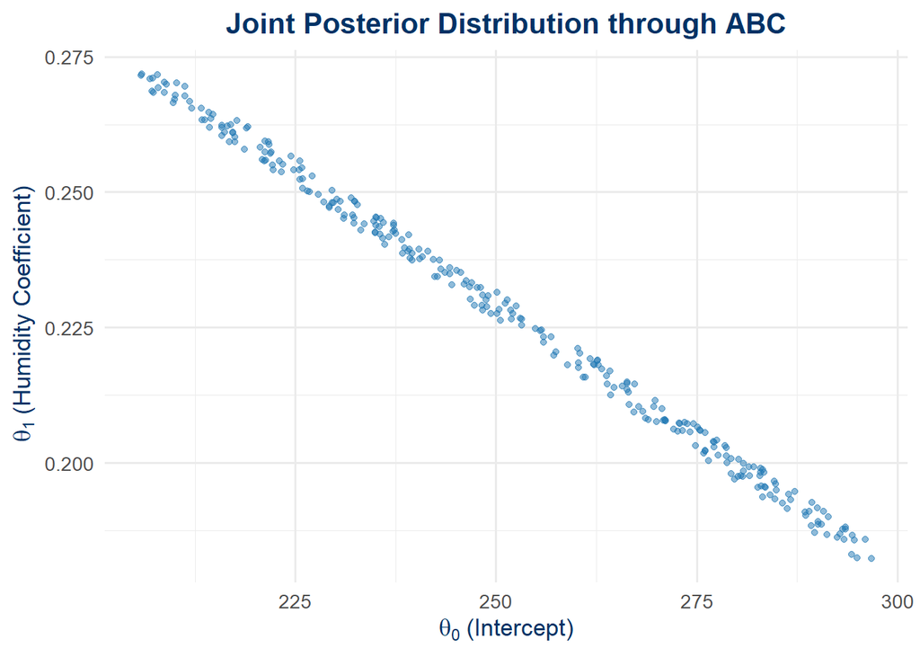

```r
# Joint Posterior Plot
ggplot(posterior_df, aes(x = theta0, y = theta1)) +
  geom_point(alpha = 0.5, color = "#1f78b4") +
  labs(
    title = "Joint Posterior Distribution through ABC",
    x = expression(theta[0] ~ "(Intercept)"),
    y = expression(theta[1] ~ "(Humidity Coefficient)")
  ) +
  theme_minimal(base_size = 13) +
  theme(
    plot.title = element_text(face = "bold", hjust = 0.5, color = "#003366"),
    axis.title = element_text(face = "bold", color = "#003366")
  )
```

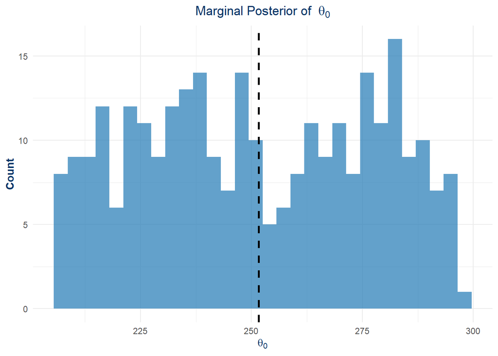

```r
# Marginal Posterior of θ₀ (Intercept)
ggplot(posterior_df, aes(x = theta0)) +
  geom_histogram(bins = 30, fill = "#1f78b4", alpha = 0.7) +
  geom_vline(xintercept = theta_fixed["intercept"], color = "black", linetype = "dashed", linewidth = 1) +
  labs(
    title = expression("Marginal Posterior of " ~ theta[0]),
    x = expression(theta[0]), y = "Count"
  ) +
  theme_minimal() +
  theme(
    plot.title = element_text(face = "bold", hjust = 0.5, color = "#003366"),
    axis.title = element_text(face = "bold", color = "#003366")
  )
```

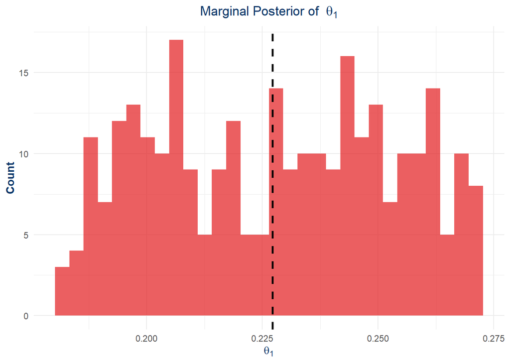

```r
#  Marginal Posterior of θ₁ (Humidity)
ggplot(posterior_df, aes(x = theta1)) +
  geom_histogram(bins = 30, fill = "#e31a1c", alpha = 0.7) +
  geom_vline(xintercept = theta_fixed["humidity"], color = "black", linetype = "dashed", linewidth = 1) +
  labs(
    title = expression("Marginal Posterior of " ~ theta[1]),
    x = expression(theta[1]), y = "Count"
  ) +
  theme_minimal() +
  theme(
    plot.title = element_text(face = "bold", hjust = 0.5, color = "#003366"),
    axis.title = element_text(face = "bold", color = "#003366")
  )
```

```r
# Create posterior summary table
posterior_summary <- data.frame(
  Parameter = c("θ₀ (Intercept)", "θ₁ (Humidity)"),
  Mean = c(mean(accepted_theta0), mean(accepted_theta1)),
  SD   = c(sd(accepted_theta0), sd(accepted_theta1))
)

posterior_summary %>%
  kbl(
    caption = "Posterior Summary (ABC Accepted Parameters)",
    align = "c"
  ) %>%
  kable_styling(
    bootstrap_options = c("striped", "hover", "condensed"),
    full_width = FALSE,
    position = "center"
  ) %>%
  row_spec(0, bold = TRUE, background = "#2c3e50", color = "white")
```

Posterior Summary (ABC Accepted Parameters)

| Parameter | Mean | SD |
| --- | --- | --- |
| θ₀ (Intercept) | 251.2623103 | 26.0595446 |
| θ₁ (Humidity) | 0.2277952 | 0.0254958 |